# Schmidt_Emily_TP3

Emily Schmidt

2024-01-06

# 1 Exercise 4

For this exercise we propose to simulate a more complex scenario. To do so, we will rely on simple models (in order to avoid more difficulties, although it is just slightly more complex). The problem here is to compute the probability that the paperback sales will exceed the hardcover sales next time. Let $y_{t+1}$ be the paperback and $w_{t+1}$ be the hardcover. Thus, we want to compute $P(y_{t+1} > w_{t+1})$. Since these are two random variables, one possibility is to simulate $y_{t+1}$ and$w_{t+1}$ and then estimate the proportion of y.simu > w.simu.

```
## Time Series:
## Start = 1
## End = 10
## Frequency = 1
##    Paperback Hardcover
##  1       199       139
##  2       172       128
##  3       111       172
##  4       209       139
##  5       161       191
##  6       119       168
##  7       195       170
##  8       195       145
##  9       131       184
## 10       183       135
```

```
##  Time-Series [1:30, 1:2] from 1 to 30: 199 172 111 209 161 119 195 195 131 183 ...
##  - attr(*, "dimnames")=List of 2
##   ..$ : NULL
##   ..$ : chr [1:2] "Paperback" "Hardcover"
```

```
## [1] 30  2
```

```
##  [1] 199 172 111 209 161 119 195 131 183 143 141 168 201 155 243 225 167 237 202
## [20] 186 176 232 190 182 222 217 188 247 139 128 191 170 145 184 135 218 198 230
## [39] 206 240 189 158 178 261 238 214 200 283 220 259
```

```
## # A tsibble: 30 x 3 [1]
##     Time Paperback Hardcover
##    <dbl>     <int>     <int>
##  1     1       199       139
##  2     2       172       128
##  3     3       111       172
##  4     4       209       139
##  5     5       161       191
##  6     6       119       168
##  7     7       195       170
##  8     8       195       145
##  9     9       131       184
## 10    10       183       135
## # ℹ 20 more rows
```

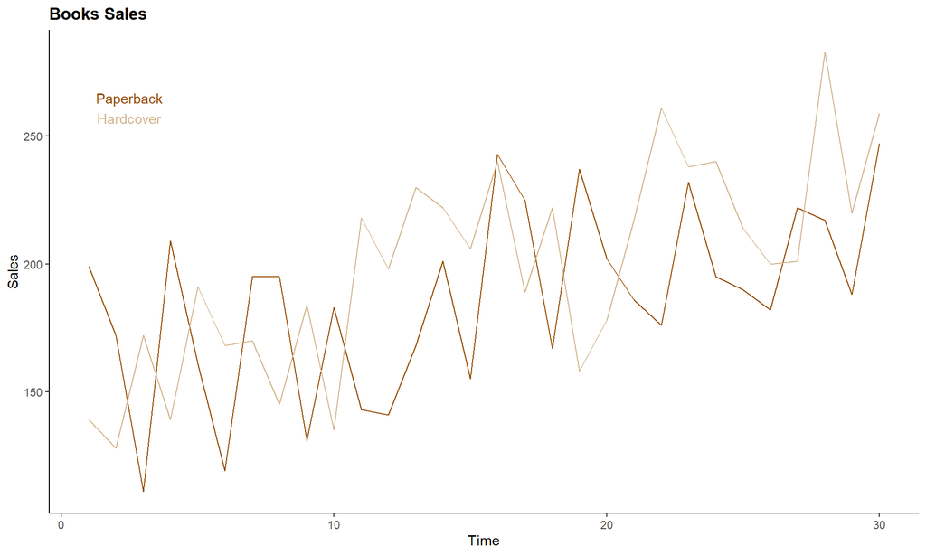

Both types of books appear to have a positive trend with no seasonality. Therefore, the analysis will continue to use Holt’s ETS(A, A, N). When there were higher sales in hardcover books for a period of time (~ 11 to 17), paperback books were not selling as much. To dive deeper, an employee from the book store may be able to provide additional insight. The hardcovers appears to have less fluctuation in sales in the beginning of time compared to paperbacks, but the inverse happened towards time 30.

## 1.1 Question a

Set the two Holt’s model with additive ETS(A,A,N).

Holt’s linear method with additive errors is produced twice for each type of book, paperback and hardback. Under this model, it is assumed that the one-step-ahead training errors are given by:
$$\epsilon_t = y_t - ℓ_{t-1} - b_{t-1} ~
NID(0, \sigma^2)$$
(Chapter 8.5) By substituting this error correction into Holt’s linear model, we obtain:

- $y_t = ℓ_{t-1} + b_{t-1} + \epsilon_t$
- $ℓ_t = ℓ_{t-1} + b_{t-1} + \alpha\epsilon_t$
- $b_t = b_{t-1} + \beta\epsilon_t$

### 1.1.1 Holt’s Model - Paperback

```
## Series: Paperback
## Model: ETS(A,A,N)
##   Smoothing parameters:
##     alpha = 0.0001002281
##     beta  = 0.0001000024
##
##   Initial states:
##     l[0]     b[0]
##  170.699 1.261911
##
##   sigma^2:  1118.663
##
##      AIC     AICc      BIC
## 318.3396 320.8396 325.3456
```

```
## # A tibble: 1 × 10
##   .model        .type       ME  RMSE   MAE   MPE  MAPE  MASE RMSSE   ACF1
##   <chr>         <chr>    <dbl> <dbl> <dbl> <dbl> <dbl> <dbl> <dbl>  <dbl>
## 1 Holt's method Training -3.71  31.1  26.2 -5.51  15.6 0.660 0.659 -0.175
```

```
## # A dable: 31 x 6 [1]
## # Key:     .model [1]
## # :        Paperback = lag(level, 1) + lag(slope, 1) + remainder
##    .model         Time Paperback level slope remainder
##    <chr>         <dbl>     <int> <dbl> <dbl>     <dbl>
##  1 Holt's method     0        NA  171.  1.26     NA
##  2 Holt's method     1       199  172.  1.26     27.0
##  3 Holt's method     2       172  173.  1.26     -1.23
##  4 Holt's method     3       111  174.  1.26    -63.5
##  5 Holt's method     4       209  176.  1.26     33.3
##  6 Holt's method     5       161  177.  1.26    -16.0
##  7 Holt's method     6       119  178.  1.25    -59.3
##  8 Holt's method     7       195  180.  1.26     15.5
##  9 Holt's method     8       195  181.  1.26     14.2
## 10 Holt's method     9       131  182.  1.25    -51.0
## # ℹ 21 more rows
```

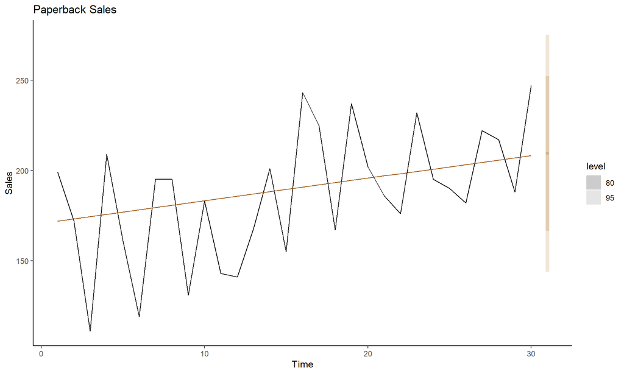

```
## Series: Paperback
## Model: ETS(A,N,N)
##   Smoothing parameters:
##     alpha = 0.168421
##
##   Initial states:
##      l[0]
##  170.8464
##
##   sigma^2:  1212.315
##
##      AIC     AICc      BIC
## 318.9747 319.8978 323.1783
```

```
## # A tibble: 1 × 10
##   .model .type       ME  RMSE   MAE   MPE  MAPE  MASE RMSSE   ACF1
##   <chr>  <chr>    <dbl> <dbl> <dbl> <dbl> <dbl> <dbl> <dbl>  <dbl>
## 1 SES    Training  7.18  33.6  27.8 0.473  15.6 0.702 0.712 -0.212
```

```
## # A dable: 31 x 5 [1]
## # Key:     .model [1]
## # :        Paperback = lag(level, 1) + remainder
##    .model  Time Paperback level remainder
##    <chr>  <dbl>     <int> <dbl>     <dbl>
##  1 SES        0        NA  171.     NA
##  2 SES        1       199  176.     28.2
##  3 SES        2       172  175.     -3.59
##  4 SES        3       111  164.    -64.0
##  5 SES        4       209  172.     44.8
##  6 SES        5       161  170.    -10.8
##  7 SES        6       119  161.    -50.9
##  8 SES        7       195  167.     33.6
##  9 SES        8       195  172.     28.0
## 10 SES        9       131  165.    -40.7
## # ℹ 21 more rows
```

Although **question a** asks to use ETS(A, A, N), using model() will show that for paperback books, the ETS(A, N, N) may be better. This is a strange result since both the AIC and RMSE is better in the original method.

### 1.1.2 Holt’s Model - Hardcover

```
## Series: Hardcover
## Model: ETS(A,A,N)
##   Smoothing parameters:
##     alpha = 0.0001000484
##     beta  = 0.0001000231
##
##   Initial states:
##      l[0]     b[0]
##  147.7935 3.302946
##
##   sigma^2:  853.2586
##
##      AIC     AICc      BIC
## 310.2148 312.7148 317.2208
```

```
## # A tibble: 1 × 10
##   .model        .type        ME  RMSE   MAE   MPE  MAPE  MASE RMSSE    ACF1
##   <chr>         <chr>     <dbl> <dbl> <dbl> <dbl> <dbl> <dbl> <dbl>   <dbl>
## 1 Holt's method Training -0.135  27.2  23.2 -2.11  12.2 0.691 0.683 -0.0325
```

```
## # A dable: 31 x 6 [1]
## # Key:     .model [1]
## # :        Hardcover = lag(level, 1) + lag(slope, 1) + remainder
##    .model         Time Hardcover level slope remainder
##    <chr>         <dbl>     <int> <dbl> <dbl>     <dbl>
##  1 Holt's method     0        NA  148.  3.30    NA
##  2 Holt's method     1       139  151.  3.30   -12.1
##  3 Holt's method     2       128  154.  3.30   -26.4
##  4 Holt's method     3       172  158.  3.30    14.3
##  5 Holt's method     4       139  161.  3.30   -22.0
##  6 Holt's method     5       191  164.  3.30    26.7
##  7 Holt's method     6       168  168.  3.30     0.405
##  8 Holt's method     7       170  171.  3.30    -0.896
##  9 Holt's method     8       145  174.  3.30   -29.2
## 10 Holt's method     9       184  177.  3.30     6.51
## # ℹ 21 more rows
```

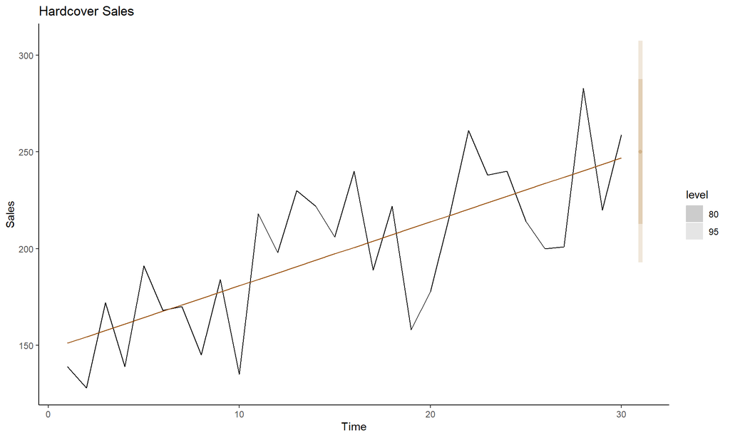

```
## Series: Hardcover
## Model: ETS(M,A,N)
##   Smoothing parameters:
##     alpha = 0.0001000081
##     beta  = 0.0001000008
##
##   Initial states:
##      l[0]     b[0]
##  149.3465 3.255442
##
##   sigma^2:  0.0214
##
##     AIC    AICc     BIC
## 309.583 312.083 316.589
```

```
## # A tibble: 1 × 10
##   .model .type        ME  RMSE   MAE   MPE  MAPE  MASE RMSSE    ACF1
##   <chr>  <chr>     <dbl> <dbl> <dbl> <dbl> <dbl> <dbl> <dbl>   <dbl>
## 1 SES    Training -0.932  27.2  23.2 -2.57  12.2 0.691 0.683 -0.0328
```

```
## # A dable: 31 x 6 [1]
## # Key:     .model [1]
## # :        Hardcover = (lag(level, 1) + lag(slope, 1)) * (1 + remainder)
##    .model  Time Hardcover level slope remainder
##    <chr>  <dbl>     <int> <dbl> <dbl>     <dbl>
##  1 SES        0        NA  149.  3.26  NA
##  2 SES        1       139  153.  3.25  -0.0891
##  3 SES        2       128  156.  3.25  -0.179
##  4 SES        3       172  159.  3.25   0.0811
##  5 SES        4       139  162.  3.25  -0.144
##  6 SES        5       191  166.  3.25   0.153
##  7 SES        6       168  169.  3.25  -0.00509
##  8 SES        7       170  172.  3.25  -0.0123
##  9 SES        8       145  175.  3.25  -0.173
## 10 SES        9       184  179.  3.25   0.0302
## # ℹ 21 more rows
```

## 1.2 Question b

Simulate two (2) sets of 1000 random normal variables associated with each model.

Simulations can be used in a variety of situations. In this scenario, we approach the problem by:

1. Simulating a random sample of independent errors from $N(0, σ^2)$
2. Applying the state space model to build a random sample of path for $y_{t+1}, . . . , y_{t+h}$
3. Computing the characteristics of the distribution you are interested in (shape, variability, etc.)

```
## # A dable: 31 x 6 [1]
## # Key:     .model [1]
## # :        Paperback = lag(level, 1) + lag(slope, 1) + remainder
##    .model         Time Paperback level slope remainder
##    <chr>         <dbl>     <int> <dbl> <dbl>     <dbl>
##  1 Holt's method     0        NA  171.  1.26     NA
##  2 Holt's method     1       199  172.  1.26     27.0
##  3 Holt's method     2       172  173.  1.26     -1.23
##  4 Holt's method     3       111  174.  1.26    -63.5
##  5 Holt's method     4       209  176.  1.26     33.3
##  6 Holt's method     5       161  177.  1.26    -16.0
##  7 Holt's method     6       119  178.  1.25    -59.3
##  8 Holt's method     7       195  180.  1.26     15.5
##  9 Holt's method     8       195  181.  1.26     14.2
## 10 Holt's method     9       131  182.  1.25    -51.0
## # ℹ 21 more rows
```

```
## # A dable: 31 x 6 [1]
## # Key:     .model [1]
## # :        Hardcover = lag(level, 1) + lag(slope, 1) + remainder
##    .model         Time Hardcover level slope remainder
##    <chr>         <dbl>     <int> <dbl> <dbl>     <dbl>
##  1 Holt's method     0        NA  148.  3.30    NA
##  2 Holt's method     1       139  151.  3.30   -12.1
##  3 Holt's method     2       128  154.  3.30   -26.4
##  4 Holt's method     3       172  158.  3.30    14.3
##  5 Holt's method     4       139  161.  3.30   -22.0
##  6 Holt's method     5       191  164.  3.30    26.7
##  7 Holt's method     6       168  168.  3.30     0.405
##  8 Holt's method     7       170  171.  3.30    -0.896
##  9 Holt's method     8       145  174.  3.30   -29.2
## 10 Holt's method     9       184  177.  3.30     6.51
## # ℹ 21 more rows
```

From the outputs above, the reader will notice that the last observation’s trend and levels for the hardcover and paperback books were computed. These are needed to calculate the models’ mean and standard deviation.

```
## Series: Paperback
## Model: ETS(A,A,N)
##   Smoothing parameters:
##     alpha = 0.0001002281
##     beta  = 0.0001000024
##
##   Initial states:
##     l[0]     b[0]
##  170.699 1.261911
##
##   sigma^2:  1118.663
##
##      AIC     AICc      BIC
## 318.3396 320.8396 325.3456
```

```
## [1] 33.44642
```

```
## [1] 209.4602
```

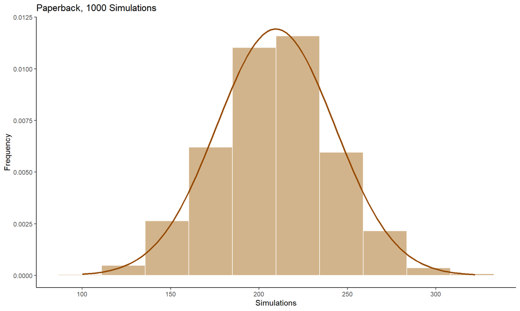

```
## Series: Hardcover
## Model: ETS(A,A,N)
##   Smoothing parameters:
##     alpha = 0.0001000484
##     beta  = 0.0001000231
##
##   Initial states:
##      l[0]     b[0]
##  147.7935 3.302946
##
##   sigma^2:  853.2586
##
##      AIC     AICc      BIC
## 310.2148 312.7148 317.2208
```

```
## [1] 29.21059
```

```
## [1] 250.172
```

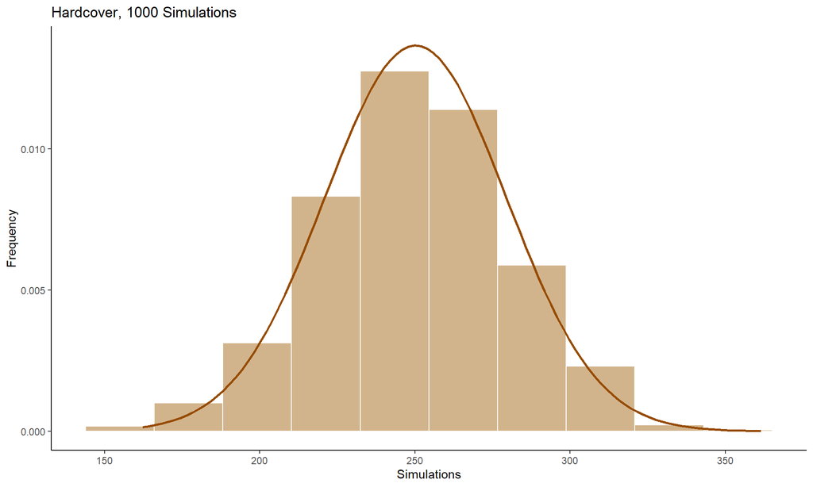

For each Holt model, the mean and variance (derived the standard deviation) were used to compute the 1,000 random variables that were plotted in each histogram. Both plots appear to be normally distributed with the following metrics:

*Paperback Model*

- Mean: 209.46
- Sigma: 33.45
- AIC: 318.3396

*Hardcover Model*

- Mean: 250.172
- Sigma: 29.21
- AIC: 310.2148

## 1.3 Question c

Estimate the probability $P(y_{t+1} > w_{t+1})$ for the corresponding proportion.

```
## [1] 17.6178
```

```
## [1] 16.3
```

```
## [1] 15.9
```

## 1.4 Question d

Under which assumptions the computation on the point *c*. before can be performed?

The simulations should be normally distributed. Therefore, the assumption for the additive errors within both models should be independent and identically distribution over time. The mean and standard deviation of both paperbacks and hardcovers should remain constant over time as well.